## Projekt dotyczący metod klasyfikacji zbioru danych Student Performance

Kacper Andrzejewski 419925, gr. 1, IAD rok 3 AGH

#### Projekt polega na zastosowaniu metod uczenia maszynowego (uczenie nienadzorowane) w celu klasyfikacji danych dotyczących zbioru Student Performance zawierającego 10000 rekordów (danych na temat różnych studentów) oraz kolumny - 5 zmiennych niezależnych:

- **Hours Studied** - ilość godzin poświęcona na naukę przez studenta,
- **Previous Scores** - wyniki uzyskane przez studenta w poprzednich testach
- **Extracurricular Activities** - zmienna binarna określająca, czy student bierze udział w dodatkowych aktywnościach (teoretycznie podnoszących jego poziom wiedzy),
- **Sleep Hours** - średnia liczba godzin snu studenta,
- **Sample Question Papers Practiced** - ilość wykonanych przykładowych testów przez studenta

#### Oraz zmienną zależną, determinowaną przez powyższe:

- **Performance Index** - indeks określający miarę wyników studenta w przedziale od 10 do 100, gdzie im wyższa wartość, tym lepsze jego rezultaty.

Wszystkie zmienne (oprócz *Extracurricular Activities*) są zmiennymi numerycznymi, więc, poza wspomnianą zmienną binarną, nie ma potrzeby konwersji w celu przygotowania ich do użycia w przyszłych modelach.

### Etap 1 - wczytanie, preprocessing i wgląd do danych

```r
data_in <- read.csv("Student_Performance.csv", header=TRUE, sep=',')
head(data_in, 10)
```

```
##    Hours.Studied Previous.Scores Extracurricular.Activities Sleep.Hours
## 1              7              99                        Yes           9
## 2              4              82                         No           4
## 3              8              51                        Yes           7
## 4              5              52                        Yes           5
## 5              7              75                         No           8
## 6              3              78                         No           9
## 7              7              73                        Yes           5
## 8              8              45                        Yes           4
## 9              5              77                         No           8
## 10             4              89                         No           4
##    Sample.Question.Papers.Practiced Performance.Index
## 1                                 1                91
## 2                                 2                65
## 3                                 2                45
## 4                                 2                36
## 5                                 5                66
## 6                                 6                61
## 7                                 6                63
## 8                                 6                42
## 9                                 2                61
## 10                                0                69
```

Powyżej wyświetlone zostało 10 pierwszych wierszy w zbiorze danych.

```r
sum(is.na(data_in))
```

```
## [1] 0
```

Zgodnie z wynikiem powyższego kodu, w zbiorze danych nie ma brakujących wartości (*Missing Values* - *NA*), więc nie ma potrzeby usuwania pojedynczych wierszy bądź dokonywania imputowania.

```r
summary(data_in)
```

```
##  Hours.Studied   Previous.Scores Extracurricular.Activities  Sleep.Hours
##  Min.   :1.000   Min.   :40.00   Length:10000               Min.   :4.000
##  1st Qu.:3.000   1st Qu.:54.00   Class :character           1st Qu.:5.000
##  Median :5.000   Median :69.00   Mode  :character           Median :7.000
##  Mean   :4.993   Mean   :69.45                              Mean   :6.531
##  3rd Qu.:7.000   3rd Qu.:85.00                              3rd Qu.:8.000
##  Max.   :9.000   Max.   :99.00                              Max.   :9.000
##  Sample.Question.Papers.Practiced Performance.Index
##  Min.   :0.000                    Min.   : 10.00
##  1st Qu.:2.000                    1st Qu.: 40.00
##  Median :5.000                    Median : 55.00
##  Mean   :4.583                    Mean   : 55.22
##  3rd Qu.:7.000                    3rd Qu.: 71.00
##  Max.   :9.000                    Max.   :100.00
```

Powyżej wyświetlono podstawowe informacje statystyczne o każdej zmiennej (minima, maxima, mediany, wartości oczekiwane, pierwsze oraz trzecie kwartyle).

```r
library(dplyr)
data<- data_in %>%
  mutate(Extracurricular.Activities = ifelse(Extracurricular.Activities == "Yes", 1, 0)
         )
head(data, 10)
```

```
##    Hours.Studied Previous.Scores Extracurricular.Activities Sleep.Hours
## 1              7              99                          1           9
## 2              4              82                          0           4
## 3              8              51                          1           7
## 4              5              52                          1           5
## 5              7              75                          0           8
## 6              3              78                          0           9
## 7              7              73                          1           5
## 8              8              45                          1           4
## 9              5              77                          0           8
## 10             4              89                          0           4
##    Sample.Question.Papers.Practiced Performance.Index
## 1                                 1                91
## 2                                 2                65
## 3                                 2                45
## 4                                 2                36
## 5                                 5                66
## 6                                 6                61
## 7                                 6                63
## 8                                 6                42
## 9                                 2                61
## 10                                0                69
```

Powyżej zmienna jakościowa (binarna) *Extracurricular Activities* została przetransformowana na wartości typu float - “No” oznacza 0, natomiast “Yes” odpowiada 1 (binarna).

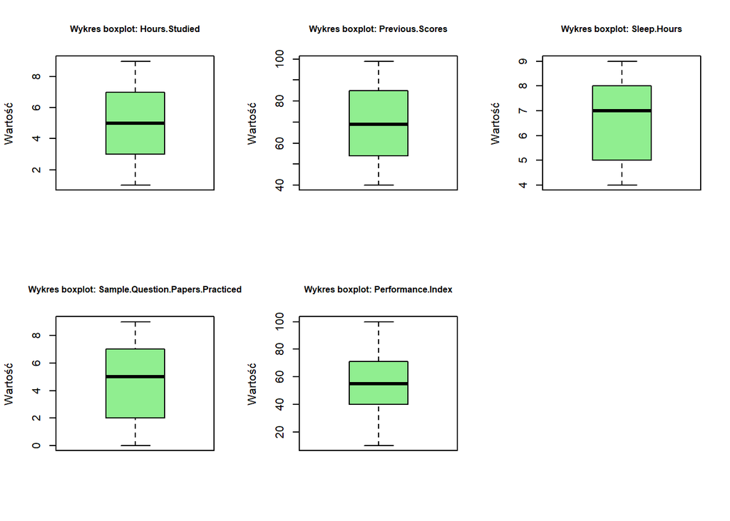

```r
num_data <- data[,c(1,2,4,5,6)]
par(mfrow=c(2,3))
for (i in 1:ncol(num_data)) {
  boxplot(num_data[, i],
          main = paste("Wykres boxplot:", names(num_data)[i]),
          cex.main=0.77,
          col='lightgreen',
          ylab='Wartość',
          outpch=19,
          outcol='red')
}
```

Powyżej zostały wyświetlone wykresy typu ramka-wąsy dla wszystkich zmiennych numerycznych (niebinarnych), aby przedstawić graficznie rozkład wartości w każdej kolumnie. Wartości odstające (tzw. *Outliers*) powinny być oznaczone jako czerwone punkty, lecz brakuje ich na wykresach, co oznacza, że w danych nie występują wartości tego typu. Dla pewności oraz dokładniejszego zobrazowania rozkładu wartości zmiennych poniżej wykonano histogramy tych samych zmiennych. Ilość przedziałow histogramu została wyznaczona za pomocą *reguły Scotta*, ponieważ jest ona odpowiednim wyborem do tego zbioru danych, gdyż nie posiada on wartości odstających oraz ma dużą ilość rekordów (10000).

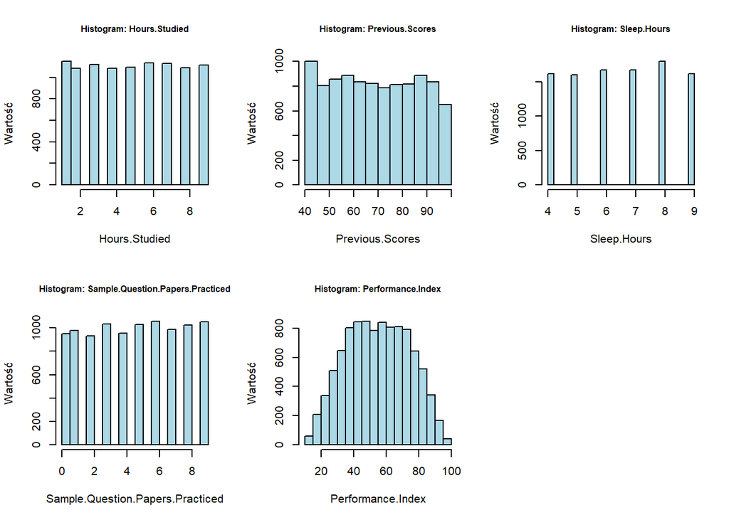

```r
par(mfrow=c(2,3))
for (i in 1:ncol(num_data)) {
  hist(num_data[, i],
          main = paste("Histogram:", names(num_data)[i]),
          breaks="Scott",
          cex.main=0.77,
          col='lightblue',
          ylab='Wartość',
          xlab = names(num_data)[i])
}
```

Jak widać powyżej, niektóre zmienne ze względu na istotę swoich wartości mają histogramy z oddzielonymi słupkami, lecz wynika to z natury danych zmiennych oraz zastosowania odpowiedniej reguły podziału wykresu, aby poprawnie przedstawić zmienne *Previous Scores* oraz *Performance Index*, które mają ciągły charakter histogramu. Ponownie potwierdzono tezę, iż w danych nie występują wartości odstające.

### Etap 2 - Przygotowanie danych do wykonania modeli

```r
set.seed(419925)
sets <- sample(1:nrow(data), 0.7 * nrow(data))
train_raw <- data[sets, ]
temp_raw <- data[-sets, ]

random4 <- sample(1:nrow(temp_raw), 4)
val_raw <- temp_raw[-random4, ]
test_raw <- temp_raw[random4, ]
```

Powyżej został dokonany podział zbioru danych na treningowy (70% zbioru danych), testowy do predykcji metodą k-najbliższych sąsiadów (4 losowe obserwacje) oraz walidacyjny do oceny skuteczności na zbiorze (pozostałe 30% bez 4 testowych obserwacji).

```r
stand <- function(x) { (x - mean(x)) / sd(x) }
train_std <- train_raw
train_std[, 1:5] <- as.data.frame(lapply(train_raw[, 1:5], stand))

train_means <- sapply(train_raw[, 1:5], mean)
train_sds <- sapply(train_raw[, 1:5], sd)
val_std <- val_raw
test_std <- test_raw

for(i in 1:5) {
  val_std[, i] <- (val_raw[, i] - train_means[i]) / train_sds[i]
  test_std[, i] <- (test_raw[, i] - train_means[i]) / train_sds[i]
}
```

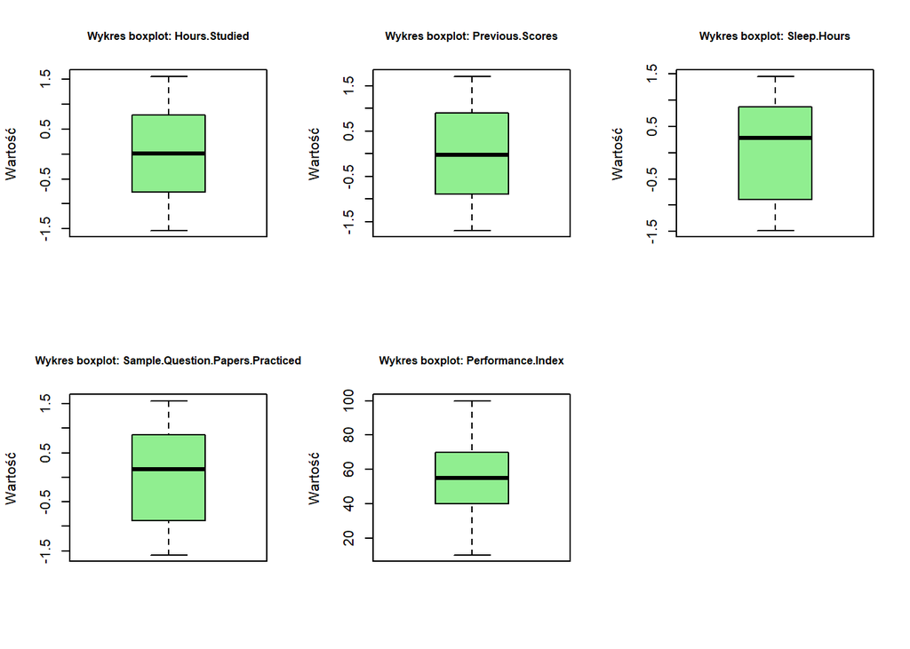

```r
num_train_std <- train_std[,c(1,2,4,5,6)]
par(mfrow=c(2,3))
for (i in 1:ncol(num_train_std)) {
  boxplot(num_train_std[, i],
          main = paste("Wykres boxplot:", names(num_train_std)[i]),
          cex.main=0.77,
          col='lightgreen',
          ylab='Wartość',
          outpch=19,
          outcol='red')
}
```

```r
summary(train_std)
```

```
##  Hours.Studied      Previous.Scores    Extracurricular.Activities
##  Min.   :-1.53798   Min.   :-1.69702   Min.   :-0.9942
##  1st Qu.:-0.76301   1st Qu.:-0.88775   1st Qu.:-0.9942
##  Median : 0.01196   Median :-0.02068   Median :-0.9942
##  Mean   : 0.00000   Mean   : 0.00000   Mean   : 0.0000
##  3rd Qu.: 0.78692   3rd Qu.: 0.90420   3rd Qu.: 1.0057
##  Max.   : 1.56189   Max.   : 1.71347   Max.   : 1.0057
##   Sleep.Hours      Sample.Question.Papers.Practiced Performance.Index
##  Min.   :-1.4856   Min.   :-1.5891                  Min.   : 10.00
##  1st Qu.:-0.8974   1st Qu.:-0.8891                  1st Qu.: 40.00
##  Median : 0.2790   Median : 0.1609                  Median : 55.00
##  Mean   : 0.0000   Mean   : 0.0000                  Mean   : 55.06
##  3rd Qu.: 0.8672   3rd Qu.: 0.8609                  3rd Qu.: 70.00
##  Max.   : 1.4554   Max.   : 1.5609                  Max.   :100.00
```

Powyżej dokonano standaryzacji zmiennych niezależnych zbioru treningowego oraz wyliczono metryki danych w tym zbiorze (średnia i odchylenie standardowe), aby użyć ich do standaryzacji zmiennych niezależnych zbioru walidacyjnego oraz testowego. Dzięki temu wartości są zeskalowane tak, aby różnice między nimi nie były znaczące (w sensie bezwzględnym). Pominięcie tej czynności spowodowałoby faworyzowanie przez przyszłe modele klasyfikacyjne zmiennych o wysokich wartościach. Modele klasyfikacyjne bazują na odległościach między wartościami zmiennych w przestrzeni, więc po przeskalowaniu tych wartości, wszystkie zmienne będą traktowane przez model w równym stopniu, niezależnie od swoich wielkości. Powyżej dla podglądu rezultatów wykonano ponownie wykresy Boxplot dla zmiennych niezależnych niebinarnych zbioru treningowego oraz wyświetlono ich podstawowe statystyki.

### Etap 3 - Hierarchiczna analiza skupień - metoda aglomeracyjna

#### Metryka euklidesowa

```r
dist_e <- dist(train_std[, 1:5], method='euclidean')
m1_e <- hclust(dist_e, method='average')
m2_e <- hclust(dist_e, method='complete')
m3_e <- hclust(dist_e, method='ward.D')
m4_e <- hclust(dist_e, method='single')
```

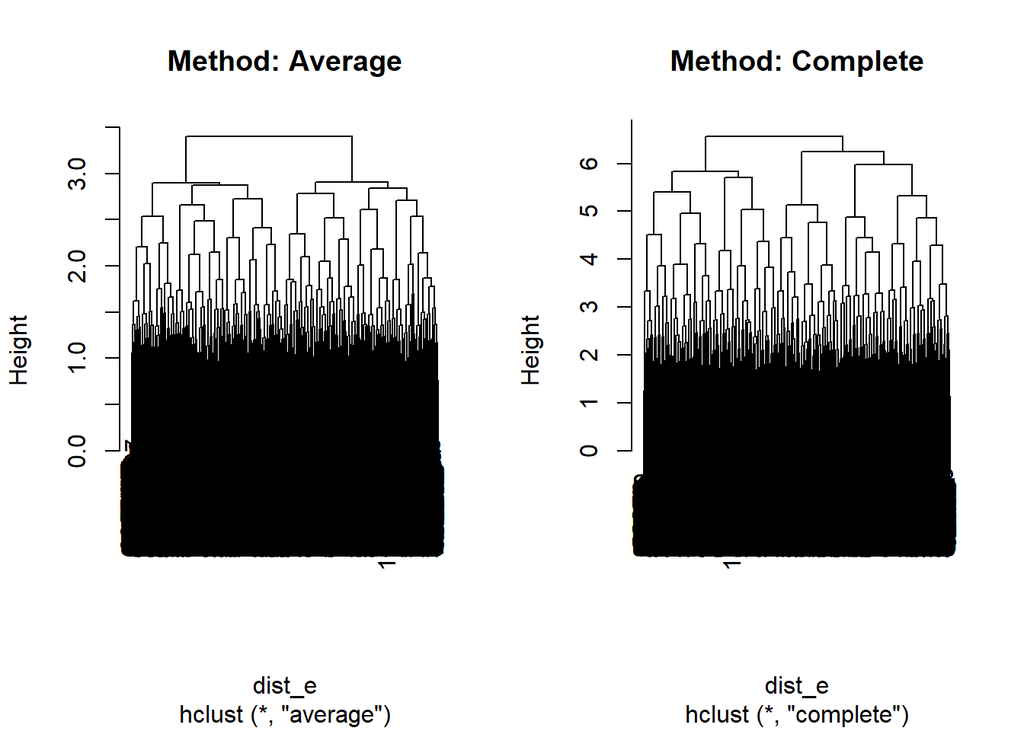

```r
par(mfrow=c(1,2))
plot(m1_e, main="Method: Average")
plot(m2_e, main="Method: Complete")
```

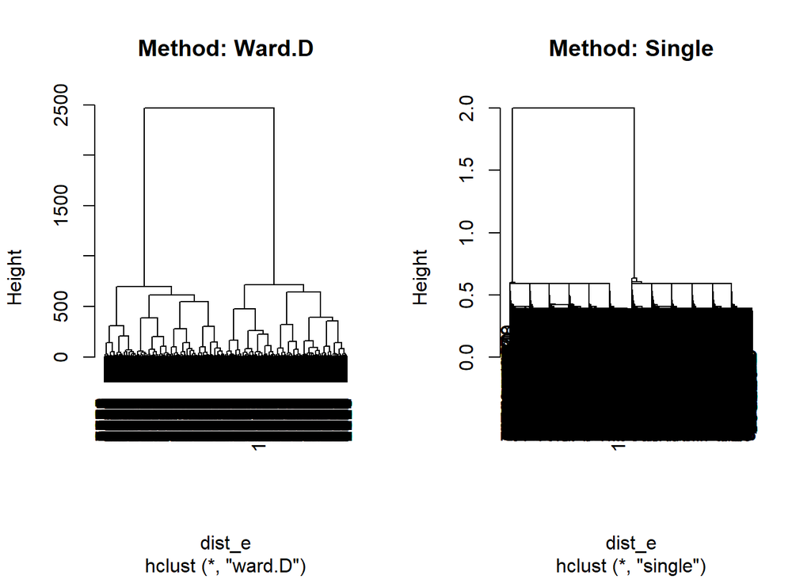

```r
par(mfrow=c(1,2))
plot(m3_e, main="Method: Ward.D")
plot(m4_e, main="Method: Single")
```

Po analizie jakościowej wykresów (dendrogramów) dla 4 różnych metod liczenia dystansów (*single*, *average*, *complete*, *ward.D*) można wysunąć następujące wnioski:  
* **Metoda Average** - optymalną wartością dla k jest 2, ponieważ dla dalszych podgrup klastry są coraz mniej zwarte i coraz bliżej siebie,  
* **Metoda Complete** - optymalną wartością dla k jest 3, ponieważ zauważalny jest ostatni wyraźny podział głównych gałęzi na corazto mniejsze podgrupy,  
* **Metoda Ward.D** - optymalną wartością dla k jest 2, ponieważ większe wartości doprowadziłyby do coraz mniejszych różnicach między klastrami (zatracenie informacji). Metoda ta wykazuje się najlepszą spośród wszystkich, ponieważ ma dwie bardzo długie gałęzie na początku co, w odróżnieniu do pozostałych metod, świadczy o najlepszym podziale danych pod względem zbalansowania podgrup oraz wydzielenia różnic między nimi,  
* **Metoda Single** - brak optymalnej wartości k, ponieważ ta technika liczenia dystansu prowadzi do tzw. *efektu łańcuchowania* tworząc pojedyncze gałęzie i brak zbalansowanego wydzielenia klastrów.

Do dalszej analizy hierarchicznej analizy skupień za pomocą metryki euklidesowej uwzględnione zostaną 3 pierwsze wymienione metody spośród powyższych.

```r
cut_m1_e <- cutree(m1_e, k=2)
cut_m2_e <- cutree(m2_e, k=3)
cut_m3_e <- cutree(m3_e, k=2)
```

Powyżej nastąpiło *obcięcie* dendrogramu na ustalonych wysokościach (zgodnie z wysuniętymi poprzednio wnioskami).

```r
library(cluster)
library(clValid)

dunn(dist_e, cut_m1_e)
```

```
## [1] 0.3169535
```

```r
dunn(dist_e, cut_m2_e)
```

```
## [1] 0.02897083
```

```r
dunn(dist_e, cut_m3_e)
```

```
## [1] 0.3169535
```

Dla wspomnianych metod liczenia dystansu obliczono *indeks Dunna*, który jest miarą “jakości” podziału na grupy w zbiorze. Jest to stosunek minimalnej odległości między klastrami do maksymalnej średnicy klastra. Zatem im wyższa wartość, tym lepszy podział. Najwyższą wartością wykazały się wyniki dla metod *Average* oraz *Ward.D* osiągając tą samą wartość (0.317). Wielkość dla metody *Complete* jest o rząd niższa od pozostałych, więc metoda ta nie jest odpowiednim wyborem.

```r
print("---------------------Ward.D----------------------")
```

```
## [1] "---------------------Ward.D----------------------"
```

```r
sil_ward_e <- silhouette(cut_m3_e, dist_e)
summary(sil_ward_e)
```

```
## Silhouette of 7000 units in 2 clusters from silhouette.default(x = cut_m3_e, dist = dist_e) :
##  Cluster sizes and average silhouette widths:
##      3520      3480
## 0.2074291 0.2113621
## Individual silhouette widths:
##    Min. 1st Qu.  Median    Mean 3rd Qu.    Max.
##  0.1268  0.1855  0.2070  0.2094  0.2303  0.3071
```

```r
cat("\n---------------------Complete--------------------\n")
```

```
##
## ---------------------Complete--------------------
```

```r
sil_complete_e <- silhouette(cut_m2_e, dist_e)
summary(sil_complete_e)
```

```
## Silhouette of 7000 units in 3 clusters from silhouette.default(x = cut_m2_e, dist = dist_e) :
##  Cluster sizes and average silhouette widths:
##       3026       1457       2517
## 0.05951590 0.15060066 0.05519216
## Individual silhouette widths:
##      Min.   1st Qu.    Median      Mean   3rd Qu.      Max.
## -0.277357  0.002728  0.088369  0.076920  0.160264  0.350081
```

```r
cat("\n---------------------Average---------------------")
```

```
##
## ---------------------Average---------------------
```

```r
sil_average_e <- silhouette(cut_m1_e, dist_e)
summary(sil_average_e)
```

```
## Silhouette of 7000 units in 2 clusters from silhouette.default(x = cut_m1_e, dist = dist_e) :
##  Cluster sizes and average silhouette widths:
##      3520      3480
## 0.2074291 0.2113621
## Individual silhouette widths:
##    Min. 1st Qu.  Median    Mean 3rd Qu.    Max.
##  0.1268  0.1855  0.2070  0.2094  0.2303  0.3071
```

Powyżej został wyliczony indeks Silhouette dla wspomnianych trzech sposobów liczenia dystansów. Stanowi on miarę tego, jak dobrze poszczególne obserwacje pasują do przypisanych im klastrów (im wyższa wartość, tym lepsza separacja).  
Analizując uzyskane wyniki, można wysunąć następujące wnioski:  
* **Metody Ward.D** oraz **Average** uzyskały identyczne wyniki, osiągając najwyższą średnią wartość indeksu Silhouette na poziomie 0.2094. W obu przypadkach algorytmy wyodrębniły dwa bardzo zbliżone liczebnie klastry (3520 oraz 3480 jednostek). Fakt, że tak różne matematycznie podejścia do łączenia grup dały ten sam rezultat, świadczy o niezwykle silnej i naturalnej strukturze danych przy podziale na k=2. Średnie szerokości sylwetki w obu klastrach oscylują wokół wartości 0.21, co wskazuje na stabilne przyporządkowanie większości obserwacji,  
* **Metoda Complete** wykazała się znacznie słabszymi wynikami. Średnia wartość indeksu Silhouette wyniosła dla niej jedynie 0.076. Ponadto, minimalne wartości szerokości sylwetki dążą do poziomów ujemnych (-0.277), co sugeruje, że wiele punktów mogło zostać błędnie zaklasyfikowanych lub znajduje się na bardzo niepewnych granicach między klastrami.

Uzyskane parametry jednoznacznie potwierdzają, że optymalnym wyborem dla hierarchicznej analizy skupień w tym zbiorze danych (metryka euklidesowa) jest podział na k=2 klastry. Wynik 0.2094 jest niemal trzykrotnie lepszy niż w przypadku metody **Complete**, a zbieżność wyników metod **Ward.D** i **Average** stanowi silny dowód na obiektywność i trwałość takiego podziału.

```r
results_clus_e <- mutate(train_std[, 1:5], m1_e=cut_m3_e)
table(results_clus_e$m1_e)
```

```
##
##    1    2
## 3520 3480
```

Powyżej wyświetlono liczebność punktów we wszystkich stworzonych klastrach. Podziały są zbalansowane i zrównoważone, co oznacza, że wybrane k=2 klastrów stanowi silny i odpowiedni podział danych.

#### Metryka Manhattan

```r
dist_m <- dist(train_std[, 1:5], method='manhattan')
m1_m <- hclust(dist_m, method='average')
m2_m <- hclust(dist_m, method='complete')
m3_m <- hclust(dist_m, method='ward.D')
m4_m <- hclust(dist_m, method='single')
```

Dla porównania wykonano hierarchiczną analizę skupień, lecz dla metryki Manhattan. Wykorzystano wszystkie 4 użyte poprzednio metody wyliczania dystansów.

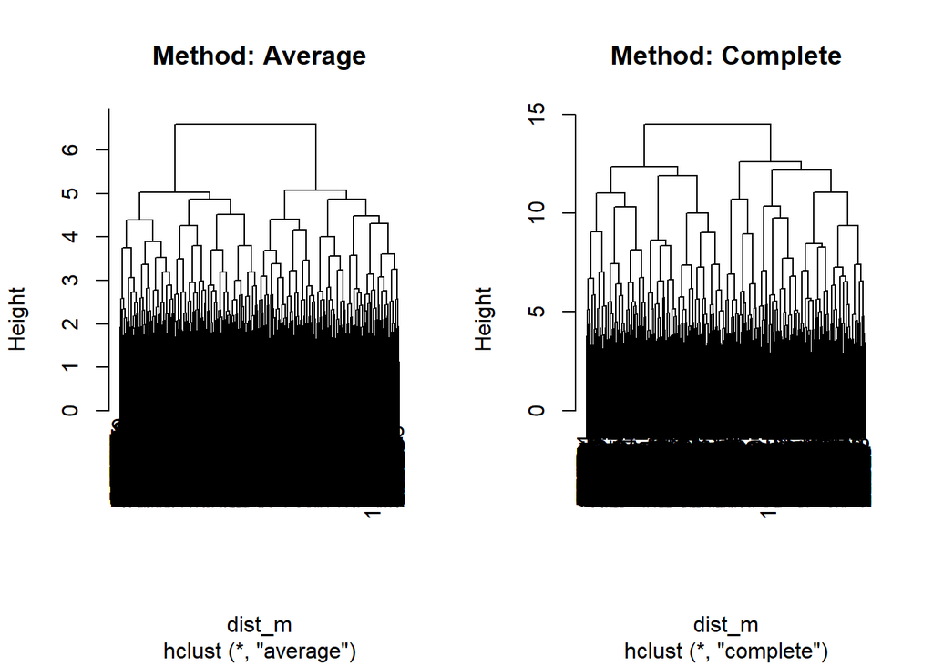

```r
par(mfrow=c(1,2))
plot(m1_m, main="Method: Average")
plot(m2_m, main="Method: Complete")
```

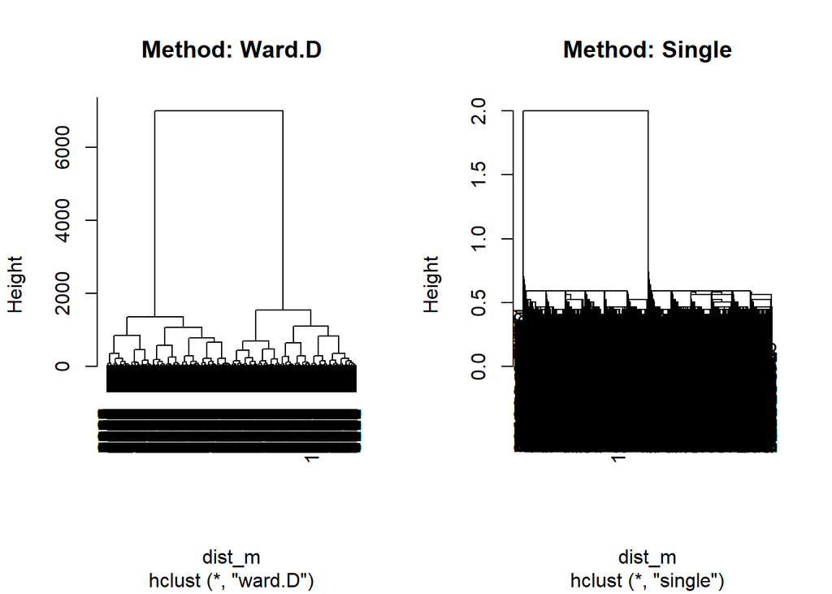

```r
par(mfrow=c(1,2))
plot(m3_m, main="Method: Ward.D")
plot(m4_m, main="Method: Single")
```

Na podstawie analizy jakościowej stworzony dendrogramów można wysunąć bardzo podobne wnioski, jak w przypadku metryki euklidesowej. Najbardziej zróżnicowanym i zbalansowanym podziałem charakteryzuje się **metoda Ward.D** (optymalną ilością klastrów jest ponownie k=2). **Metoda Average** i **metoda Complete** ponownie przedstawiają o wiele mniejsze różnice pomiędzy wydzielonymi podgrupami, natomiast klastry są umiarkowanie dobrze zbalansowane i dla odpowiednio k=2 i k=3 (dla **metody Average** i **metody Complete**) można wydzielić odpowiednio zwarte grupy (wybranie większej wartości k skutkowałoby zatraceniem różnic pomiędzy podziałami i zbyt szczegółowy podział - *“na siłę”*). Ostatnia metoda - **Single** ponownie jest nieodpowiednią techniką wyliczania dystansów, ponieważ dendrogram charakteryzuje się niepożądanym *efektem łańcuchowym*, co sprawia, iż podgrupy nie są poprawnie stworzone.

```r
cut_m1_m <- cutree(m1_m, k=2)
cut_m2_m <- cutree(m2_m, k=3)
cut_m3_m <- cutree(m3_m, k=2)
```

Powyżej dokonano *przycięcia* dendrogramów dla ustalonej dla każdej metody wartości k.

```r
dunn(dist_m, cut_m1_m)
```

```
## [1] 0.1587042
```

```r
dunn(dist_m, cut_m2_m)
```

```
## [1] 0.0186917
```

```r
dunn(dist_m, cut_m3_m)
```

```
## [1] 0.1587042
```

Dla metryki Manhattan wartości indeksu Dunna są zdecydowanie niższe niż dla poprzedniej. Oznacza to, iż spośród tych 2 metod bardziej optymalną (pod względem doboru na podstawie indeksu Dunna) jest metryka euklidesowa. Mimo ponownego wykazania się największą najwyższą wartością indeksu Dunna dla **metody Ward.D** oraz **Average** (metryka **Manhattan** - 0.1587) spośród wyliczonych 3, jest ona około 2 razy niższa niż ta sama statystyka dla metryki euklidesowej (ok. 0.31).

```r
print("---------------------Ward.D----------------------")
```

```
## [1] "---------------------Ward.D----------------------"
```

```r
sil_ward_m <- silhouette(cut_m3_m, dist_m)
summary(sil_ward_m)
```

```
## Silhouette of 7000 units in 2 clusters from silhouette.default(x = cut_m3_m, dist = dist_m) :
##  Cluster sizes and average silhouette widths:
##      3520      3480
## 0.3033970 0.3070876
## Individual silhouette widths:
##    Min. 1st Qu.  Median    Mean 3rd Qu.    Max.
##  0.2368  0.2885  0.3048  0.3052  0.3212  0.3699
```

```r
cat("\n---------------------Complete--------------------\n")
```

```
##
## ---------------------Complete--------------------
```

```r
sil_complete_m <- silhouette(cut_m2_m, dist_m)
summary(sil_complete_m)
```

```
## Silhouette of 7000 units in 3 clusters from silhouette.default(x = cut_m2_m, dist = dist_m) :
##  Cluster sizes and average silhouette widths:
##       2685        835       3480
## 0.08164768 0.24139086 0.25617062
## Individual silhouette widths:
##    Min. 1st Qu.  Median    Mean 3rd Qu.    Max.
## -0.3409  0.1101  0.2431  0.1875  0.2896  0.4187
```

```r
cat("\n---------------------Average---------------------")
```

```
##
## ---------------------Average---------------------
```

```r
sil_average_m <- silhouette(cut_m1_m, dist_m)
summary(sil_average_m)
```

```
## Silhouette of 7000 units in 2 clusters from silhouette.default(x = cut_m1_m, dist = dist_m) :
##  Cluster sizes and average silhouette widths:
##      3520      3480
## 0.3033970 0.3070876
## Individual silhouette widths:
##    Min. 1st Qu.  Median    Mean 3rd Qu.    Max.
##  0.2368  0.2885  0.3048  0.3052  0.3212  0.3699
```

W porównaniu do metryki euklidesowej, indeks Silhouette okazał się znacznie wyższy w tym przypadku (0.3052 dla **metody Ward.D** oraz **metody Average**). Mimo że metryka euklidesowa z **metodą Ward.D** dała najwyższy indeks Dunna (0.31), co sugeruje dobrą separację skrajnych grup, zdecydowano się na wybór metryki **Manhattan z metodą Warda**. Przemawia za tym znacznie wyższa średnia szerokość sylwetki (*Silhouette* = 0.31 vs 0.2094), co wskazuje na lepsze dopasowanie większości obserwacji do przypisanych im klastrów i mniejsze ryzyko błędnego zaklasyfikowania studentów znajdujących się na granicach grup. Indeks *Silhouette* w problemie klasyfikacji hierarchiczną analizą skupień dla treningowego zbioru danych wykazuje się w analizie wyższym priorytetem niż indeks *Dunna*, który pozwala jedynie na wstępny pogląd jakości podziałów.

```r
results_clus_m <- mutate(train_std[, 1:5], m1_m=cut_m3_m)
table(results_clus_m$m1_m)
```

```
##
##    1    2
## 3520 3480
```

Dla wybranej metryki oraz metody liczenia dystansów przedstawiono powyżej liczebność danych w poszczególnych podgrupach. Implikuje to fakt, iż podział jest zbalansowany i odpowiednio zróżnicowany dla k=2 ilości klastrów.

### Etap 4 - algorytm K-Średnich

Bliźniaczym algorytmem klasyfikacyjnym uczenia nienadzorowanego jest algorytm **K-Means**. Zostanie on wykonany w celu porównania wyników obu metod i wybrania odpowiedniej ilości klastrów.

```r
ratio_ss <- rep(0, 7)
for (k in 1:7) {
 models <- kmeans(train_std[, 1:5], k, nstart = 20)
 ratio_ss[k] <- models$tot.withinss / models$totss

}
```

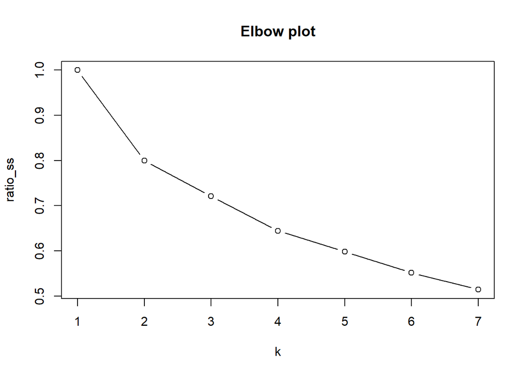

```r
plot(ratio_ss, type = "b", xlab = "k", main='Elbow plot')
```

Powyżej przedstawiono tzw. *wykres złamanego łokcia* - kryterium *złamanego kija*. Przedstawia on łamaną - *kij*, który załamuje się w pewnych momentach. Jego analiza jest pomocna przy wyborze odpowiedniej ilości klastrów dla metody **K-Means**. W tym przypadku, największe załamanie następuje w k=2, lecz widoczne jest ono również dla k=4 (bardzo małe, lecz być może kluczowe). Dla dalszych k wykres staje się liniowy, co oznacza, że dla wartości k większych od 4 nie jest możliwe wyodrębnienie kolejncyh różnic między powstałymi 4 klastrami.

```r
k2_means<-kmeans(train_std[, 1:5] ,centers=2, nstart = 20)
k4_means<-kmeans(train_std[, 1:5] ,centers=4, nstart = 20)
```

Powyżej wykonano algorytmy **k-średnich** dla wyznaczonej *metodą łokcia* wartości k (2 oraz 4).

```r
table(k2_means$cluster)
```

```
##
##    1    2
## 3520 3480
```

Powyżej pokazano liczebność danych w poszczególnych klastrach dla k=2.

```r
table(k4_means$cluster)
```

```
##
##    1    2    3    4
## 1748 1750 1772 1730
```

Powyżej wyświetlono liczebność rekordów zbioru treningowego w poszczególnych klastrach dla k=4. Podziały są bardzo zbalansowane, co implikuje założenie, iż niemalże równoliczne klastry powstałe za pomocą algorytmu **K-Średnich** dla k=2 miały bardziej subtelną strukturę i ich dodatkowy podział prawdopodobnie (k=4) wydobył kolejne różnice w poszczególnych grupach.

```r
dunn(clusters=k2_means$cluster,Data=train_std[, 1:5])
```

```
## [1] 0.3169535
```

```r
dunn(clusters=k4_means$cluster,Data=train_std[, 1:5])
```

```
## [1] 0.0104331
```

Powyżej wyznaczono *indeksy Dunna* dla wyników algorytmów **k-średnich** dla k=2 i k=4. Wyniki znacznie różnią się od siebie, ponieważ miara wspomnianego indeksu dla k=2 jest aż o rząd wyższa niż dla k=4. Oznacza to, że największe załamanie na wykonanym wykresie *złamanego łokcia* było najtrafniejszym odzwierciedleniem optymalnej ilości klastrów zadanej dla algorytmu **K-means**, a pozorny równoliczny podział danych na k=4 klastry był zatracaniem informacji i niepotrzebnym dzieleniem zbioru.

### Etap 5 - wniosek końcowy dot. metod klasyfikacji

Zarówno metoda **aglomeracyjna hierarchicznej analizy skupień** dla metryki **manhattan** z metodą **ward.D** jak i **k-means** wskazują na jednoznaczne rozwiązanie - oba są odpowiednie do zastosowania w badanym zbiorze danych. Wskaźnik Dunna dla **k-means** (k=2) wyniósł ok. 0.317, co stanowi znaczącą poprawę w stosunku do drugiej konfiguracji (k=4: 0.010). Świadczy to o istnieniu dwóch bardzo wyraźnych profili studentów w zbiorze treningowym. To sugeruje, iż oba wykonane algorytmy klasyfikacyjne jednoznacznie wskazują na optymalny dobór wartości k, równą 2. Badany zbiór ma jeden, bardzo wyraźny punkt podziału, którą **k-means** (szukający centroidów) oraz **hierarchiczna analiza skupień dla metody Warda** i **metryki Manhattan** (badająca struktrę danych) bardzo dobrze zidentyfikowały.

### Etap 6 - algorytm kNN - k-najbliższych sąsiadów

```r
train_labs <- as.factor(k2_means$cluster)
train_raw$klaster <- train_labs
```

Powyżej stworzono wektor wartości z nr klastrów na podstawie wybranego algorytmu klasyfikacyjnego (**k-means** dla k=2). Został on dodany do zbioru danych treningowych jako dodatkowa kolumna.

```r
library(clue)
val_labs <- as.factor(cl_predict(k2_means, val_std[, 1:5]))
```

Powyżej z pomocą biblioteki **clue** dodano nr przyporządkowanych klastrów do danych ze zbioru walidacyjnego z użyciem tego samego modelu, co do zbioru treningowego w poprzednich etapach projektu. Dzięki temu nie wykonano algorytmu **K-means** na podstawie zbioru walidacyjnego, lecz dodano etykiety stosując ten sam model, co w przypadku zbioru treningowego, aby sposób przypisywania był prawidłowy.

```r
library(class)

k_vals <- 2:10
accuracy <- sapply(k_vals, function(k_val) {
  pred <- knn(train = train_std[, 1:5],
              test = val_std[, 1:5],
              cl = train_labs,
              k = k_val)
  mean(pred == val_labs)
})

accuracy
```

```
## [1] 1 1 1 1 1 1 1 1 1
```

Powyżej wykonano modele **kNN** trenując model na zbiorze treningowym i testując na zbiorze walidacyjnym dla wartości k sąsiadów od 2 do 10. Metryką decydującą o jakości modelu jest **accuracy**. Jak pokazano, dla każdej wartości k accuracy wynosi 1.0, co oznacza, że algorytm **k-means** perfekcyjnie odseparował klastry a struktura danych jest niezwykle wyraźna. Dlatego też jako optymalną liczbę sąsiadów k można wybrać dowolną liczbę z analizowanego przedziału (np. k=3).

```r
final_pred_4 <- knn(train = train_std[, 1:5],
                    test = test_std[, 1:5],
                    cl = train_labs,
                    k = 3)

final_score <- data.frame(
  Obserwacja = 1:4,
  nr_klastra = final_pred_4,
  Performance.Index = test_raw$Performance.Index
)

print(final_score)
```

```
##   Obserwacja nr_klastra Performance.Index
## 1          1          2                43
## 2          2          2                78
## 3          3          1                27
## 4          4          2                70
```

Powyższe zestawienie nr klastrów, do którego zostali przyporządkowani studenci (zbiór testowy - 4 obserwacje) z indeksami wydajności, jakie są do nich przypisane prowadzi do interesującej obserwacji. Studenci wykazujący się zarówno wysokim jak i przeciętnym współczynnikiem wydajności zostali przyporządkowani do tego samego klastra. Dopiero osoba z niższą wartością *Performance.Index* została przypisana do 1 klastra. Poniżej została zestawiona średnia wartość każdej zmiennej w zbiorze treningowym dla osób w poszczególnych klastrach.

```r
aggregate(cbind(Hours.Studied, Extracurricular.Activities, Previous.Scores, Sleep.Hours, Sample.Question.Papers.Practiced, Performance.Index) ~ train_labs,
          data = train_raw,
          FUN = mean)
```

```
##   train_labs Hours.Studied Extracurricular.Activities Previous.Scores
## 1          1      4.952557                          0        69.31875
## 2          2      4.985920                          1        69.39713
##   Sleep.Hours Sample.Question.Papers.Practiced Performance.Index
## 1    6.557670                         4.515057          54.68097
## 2    6.493391                         4.565805          55.43477
```

### Etap 7 - wnioski końcowe projektu

#### Przeprowadzona analiza doprowadziła do sformułowania nieoczywistych wniosków dotyczących zbioru Student Performance. Zastosowane algorytmy k-średnich oraz k-najbliższych sąsiadów wykazały wyjątkową spójność matematyczną:

- Indeks Dunn na poziomie 0.32 świadczy o wyraźnej separacji klastrów w przestrzeni cech,
- Stuprocentowa dokładność (Accuracy) modelu kNN (1.0) potwierdza, że granice między grupami są ostre i jednoznaczne dla algorytmu.

#### Mimo tej *perfekcji* matematycznej, analiza profilowania ujawniła paradoks decyzyjny: średni wskaźnik wydajności (*Performance Index*) dla obu grup jest niemal identyczny (54.7 vs 55.4). Szczegółowe zestawienie średnich pozwoliło zidentyfikować główną przyczynę tego podziału – algorytmy dokonały segregacji studentów niemal wyłącznie na podstawie zmiennej binarnej *Extracurricular Activities*. Klaster 1 grupuje wyłącznie osoby niebiorące udziału w zajęciach dodatkowych, natomiast Klaster 2 to studenci aktywni pozalekcyjnie. Granica ta, ze względu na naturę tej zmiennej, jest na tyle oczywista, że model osiągnął bardzo dobre rezultaty (wspomniane wyżej). Jednakże, ze względu na podobne średnie wartości wskaźnika wydajności w obu klastrach, udział w zajęciach dodatkowych (który tak silnie różnicuje styl życia studentów) nie przekłada się na lepsze wyniki w nauce w tym zbiorze danych.

#### Ostatecznie, projekt udowodnił skuteczność metod klasyfikacji w rozpoznawaniu wzorców zachowań, jednocześnie obalając prostą zależność między badanymi nawykami a efektywnością nauki w tej konkretnej populacji.